# Introduction to Plotting

# Outline

- Simple plotting using default graphics tools in R
- Plotting with graphic packages in R (ggplot2)
- Visualizing data by different types of graphs in R
  - Scatter plot, line graph, bar graph, histogram, boxplot, pie chart, Venn diagram, correlation plot, heatmap
- Generate polished graph for publication and presentation

# Why using R for plotting

- When the large sample size exceed the capacity for Excel, Prism or other graphic tools
- Fast and simple
- Bundle with complicated statistical analysis
- Strong graphics capabilities makes R more popular
- Many add-on packages for various needs

# Basic plot example

```r
library("datasets")
data()
str(pressure)
```

```
'data.frame':   19 obs. of  2 variables:
 $ temperature: num  0 20 40 60 80 100 120 140 160 180 ...
 $ pressure   : num  0.0002 0.0012 0.006 0.03 0.09 0.27 0.75 1.85 4.2 8.8 ...
```

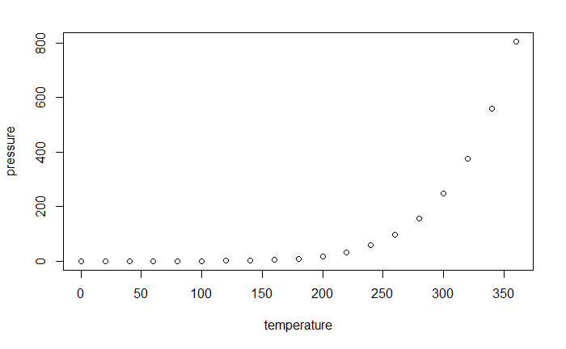

```r
View(pressure)
plot(pressure)
```

# Labels and Axes

- Default: R uses the variable names for axes labels and computes range for axes.
- Manual change by:
  - axes labels: xlab, ylab
  - size of labels: cex.lab
  - axes range: xlim, ylim

# Titles

- main: sets plot title (above plot)
- sub: sets subtitle (beneath plot)

# Symbols, colors, and lines

- type: “p” for points, “l” for lines, “b” for both, “h” for histogram-like
- pch: point symbol
- col: color
- cex: size factor
- lty: line type
- lwd: line width

# Plot symbols

#### Use the pch= option to specify symbols to use when plotting points. For symbols 21 through 25, specify border color (col=) and fill color (bg=).

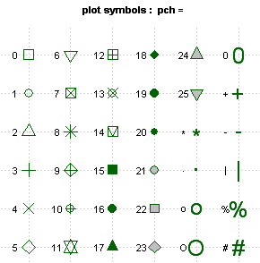

# Default color palette in R

```r
palette("default") # you'll only need this line if you've previously changed the palette from the default
palette()
```

```
[1] "black"   "red"     "green3"  "blue"    "cyan"    "magenta" "yellow"  "gray"
```

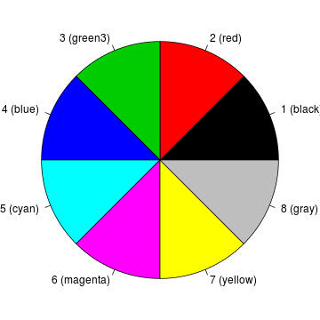

- Other R color palette options
  - rainbow(n)
  - heat.colors(n)
  - terrain.colors(n)
  - topo.colors(n)
  - cm.colors(n)
- RColorBrewer package palette

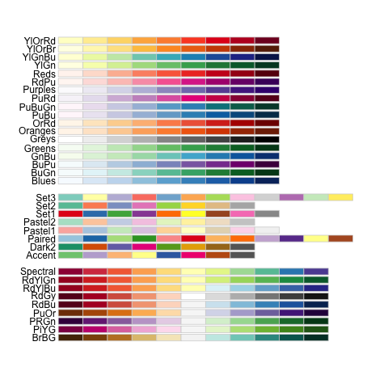

# Line types (lty= )

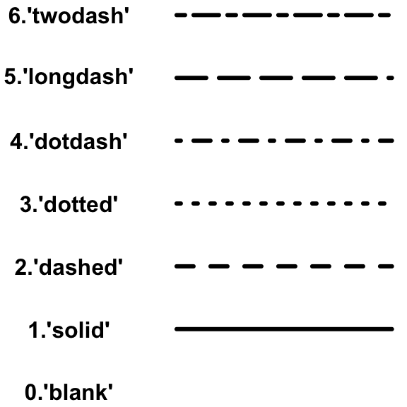

```r
par(mfrow=c(1,3))
#Solid line (by default)
plot(1:10, 1:10, type="l")
#Use dashed line type
plot(1:10, 1:10, type="l", lty=2)
```

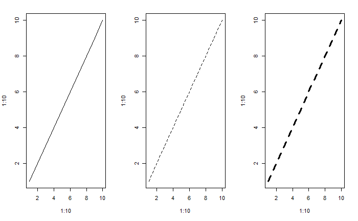

```r
#Change line width
plot(1:10, 1:10, type="l", lty=2, lwd=3)
```

# Example: plot points with formatting

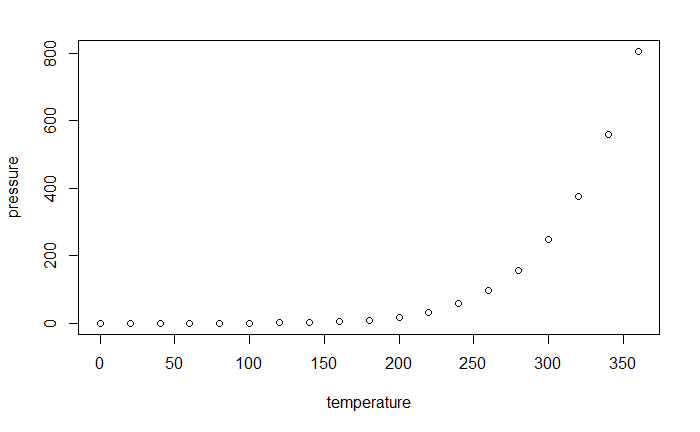

```r
plot(pressure, type="p")
```

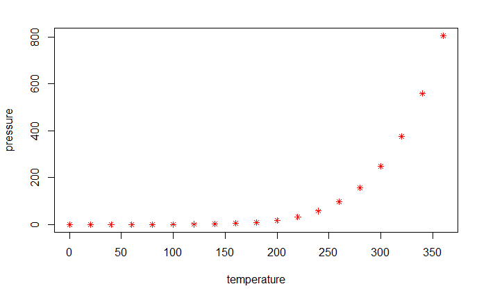

```r
plot(pressure, type="p", pch=8, cex=0.8, col="red")
```

# Example: Line graph with formatting

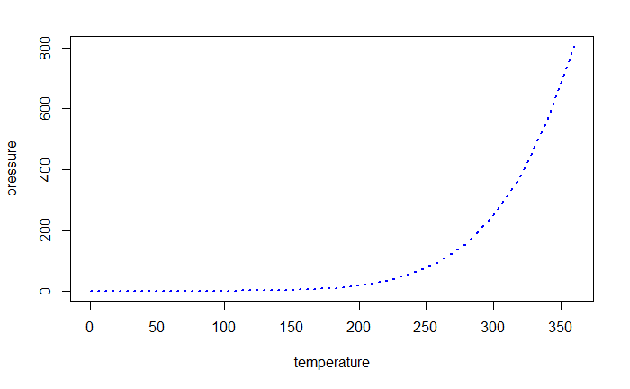

```r
plot(pressure, type="l", lty=3, lwd=2, col="blue")
```

# Example: Add title and text

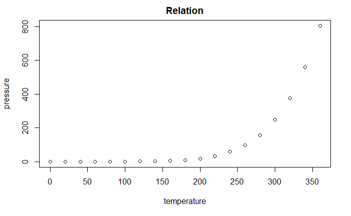

```r
plot(pressure, main="Relation")
```

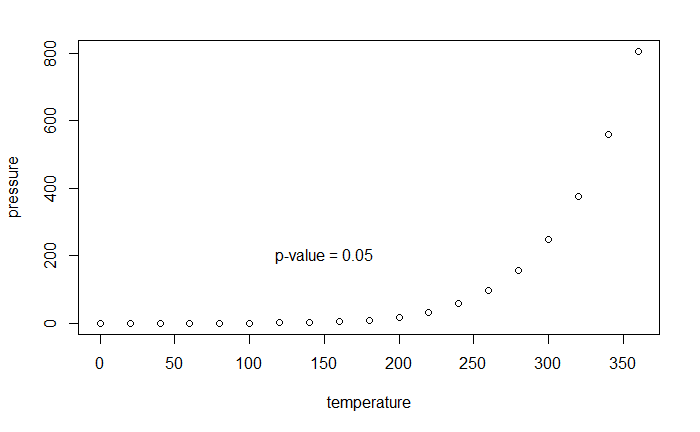

```r
plot(pressure)
text(150, 200, label="p-value = 0.05")
```

# Plot for multiple groups

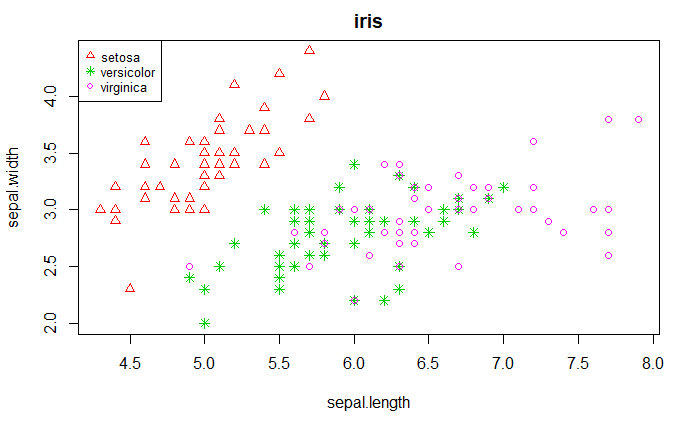

```r
data(iris) #load iris data
pch.vec <- c(2,8,21)[iris$Species]
col.vec <- c(2,3,6)[iris$Species]
plot(iris$Sepal.Length, iris$Sepal.Width, col=col.vec, pch=pch.vec, xlab="sepal.length", ylab="sepal.width", main="iris")
legend("topleft", pch=c(2,8,21), col=c(2,3,6), legend=unique(iris$Species), cex=0.8)
```

# Beyond simple graphs: ggplot2

- Hadley Wickham’s ggplots package provides a unified interface and simple set of options.
- Once you understand how ggplots works for one type of plot, you can easily apply the knowledge for any other types of plots.
- It provides beautiful and publication-ready results.
- Easy to plot for data with multiple groups and build legend automatically.

# Build-in R plotting vs. ggplot2

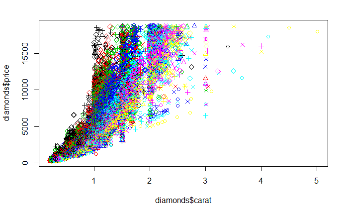

```r
library(ggplot2)
#View(diamonds)
plot(diamonds$carat, diamonds$price, col=diamonds$color, pch=as.numeric(diamonds$cut))
```

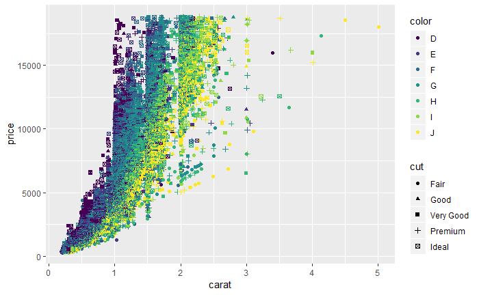

```r
ggplot(diamonds, aes(carat, price, col=color, shape=cut)) + geom_point()
```

# Scatter plot

- Display the relationship between two continuous variables

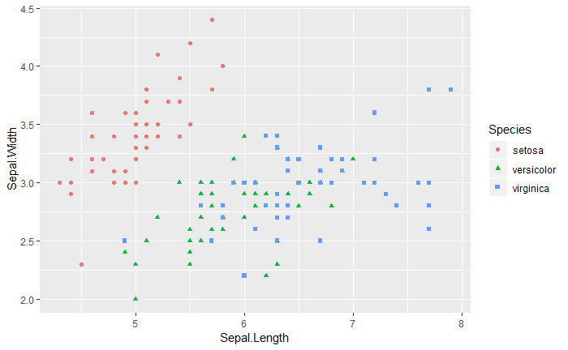

```r
ggplot(iris, aes(x=Sepal.Length, y=Sepal.Width, shape=Species, colour=Species)) + geom_point()
```

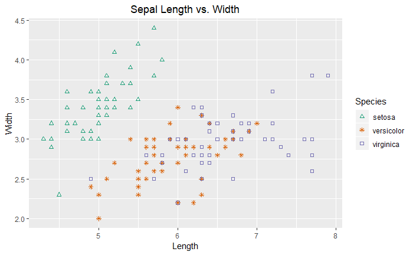

```r
ggplot(iris, aes(x=Sepal.Length, y=Sepal.Width, shape=Species, colour=Species)) + geom_point() +
  scale_color_brewer(palette="Dark2") +
  scale_shape_manual(values=c(2,8,0)) +
  labs(x="Length", y="Width", title="Sepal Length vs. Width") +
  theme(plot.title = element_text(hjust=0.5))
```

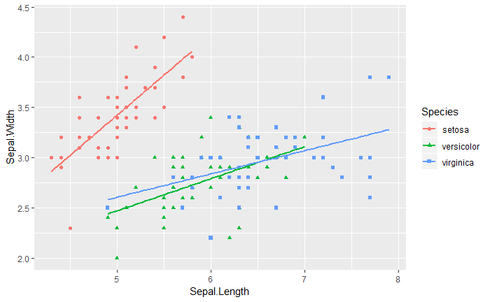

```r
ggplot(iris, aes(x=Sepal.Length, y=Sepal.Width, shape=Species, colour=Species)) + geom_point() +
  geom_smooth(method=lm,, se=FALSE)
```

# Line graph

- Trend over time or other continuous variables

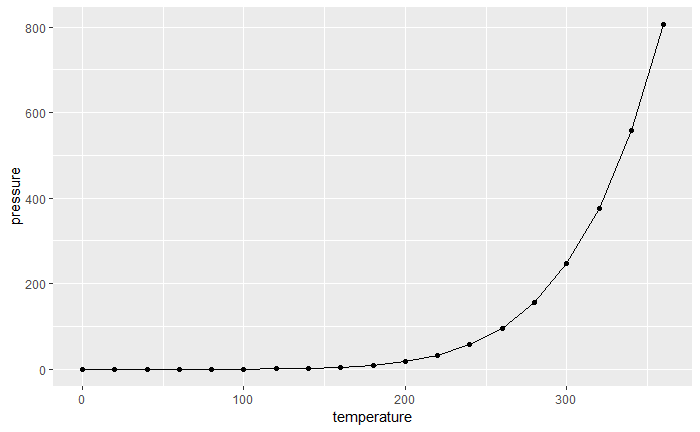

```r
ggplot(pressure, aes(x=temperature, y=pressure)) + geom_line() + geom_point()
```

# Bar graph

- Display numeric values (y-axis) for different categories (x-axis)
- Bar graph for exact values for y

```r
View(ToothGrowth)
summary(ToothGrowth)
```

```
      len        supp         dose
 Min.   : 4.20   OJ:30   Min.   :0.500
 1st Qu.:13.07   VC:30   1st Qu.:0.500
 Median :19.25           Median :1.000
 Mean   :18.81           Mean   :1.167
 3rd Qu.:25.27           3rd Qu.:2.000
 Max.   :33.90           Max.   :2.000
```

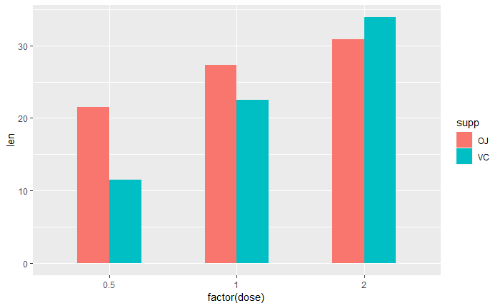

```r
ggplot(ToothGrowth, aes(x=factor(dose), y=len, fill=supp)) + geom_bar(stat="identity", position="dodge", width=0.5)
```

- Bar graph for counts of a categorical variable

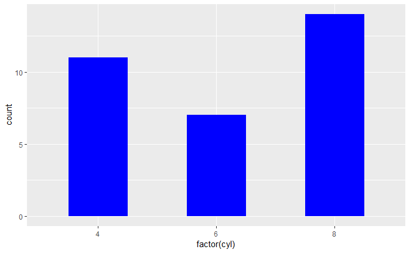

```r
ggplot(mtcars, aes(x=factor(cyl))) + geom_bar(fill="blue", width=0.5)
```

- Bar graph for percentage of a categorical variable

```r
#install.packages("asympTest")
library(asympTest)
data("DIGdata")
#for variable description, visit https://rdrr.io/cran/asympTest/man/DIGdata.html
colnames(DIGdata)
```

```
 [1] "ID"       "TRTMT"    "AGE"      "RACE"     "SEX"      "EJFPER"   "EJFMETH"  "CHESTX"   "BMI"      "KLEVEL"
[11] "CREAT"    "DIGDOSER" "CHFDUR"   "RALES"    "ELEVJVP"  "PEDEMA"   "RESTDYS"  "EXERTDYS" "ACTLIMIT" "S3"
[21] "PULCONG"  "NSYM"     "HEARTRTE" "DIABP"    "SYSBP"    "FUNCTCLS" "CHFETIOL" "PREVMI"   "ANGINA"   "DIABETES"
[31] "HYPERTEN" "DIGUSE"   "DIURETK"  "DIURET"   "KSUPP"    "ACEINHIB" "NITRATES" "HYDRAL"   "VASOD"    "DIGDOSE"
[41] "CVD"      "CVDDAYS"  "WHF"      "WHFDAYS"  "DIG"      "DIGDAYS"  "MI"       "MIDAYS"   "UANG"     "UANGDAYS"
[51] "STRK"     "STRKDAYS" "SVA"      "SVADAYS"  "VENA"     "VENADAYS" "CREV"     "CREVDAYS" "OCVD"     "OCVDDAYS"
[61] "RINF"     "RINFDAYS" "OTH"      "OTHDAYS"  "HOSP"     "HOSPDAYS" "NHOSP"    "DEATH"    "DEATHDAY" "REASON"
[71] "DWHF"     "DWHFDAYS"
```

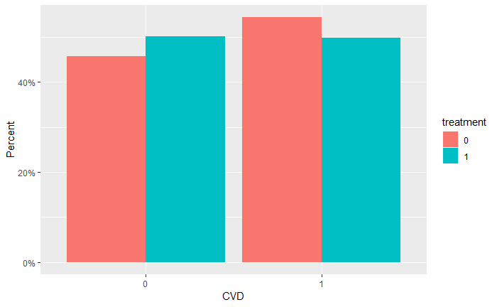

```r
ggplot(DIGdata, aes(x=factor(CVD), group=factor(TRTMT))) +
  geom_bar(aes(y=..prop.., fill=factor(TRTMT)), stat="count", position="dodge") +
  labs(x="CVD", y="Percent", fill="treatment") +
  scale_y_continuous(labels=scales::percent)
```

- Plot mean and error bars

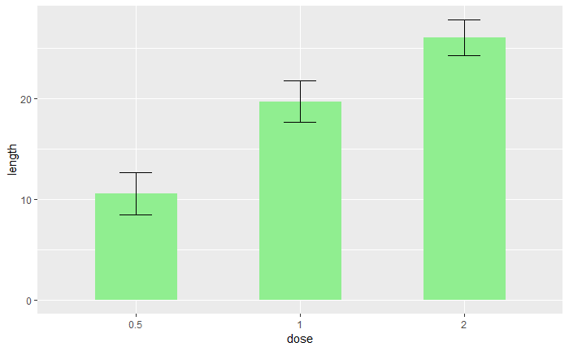

```r
#install.packages("Hmisc")
ggplot(ToothGrowth, aes(factor(dose), len)) +
  stat_summary(fun.y=mean, geom="bar", width=0.5, fill="lightgreen") +
  stat_summary(fun.data = mean_cl_normal, geom="errorbar", width=0.2) +
  labs(x="dose", y="length")
```

```r
#FYI, mean_cl_normal returns 3 summary variables: mean and lower and upper Gaussian confidence limits based on the t-distribution
```

# Visualize the data distribution

- Histogram

```r
summary(ChickWeight)
```

```
     weight           Time           Chick     Diet
 Min.   : 35.0   Min.   : 0.00   13     : 12   1:220
 1st Qu.: 63.0   1st Qu.: 4.00   9      : 12   2:120
 Median :103.0   Median :10.00   20     : 12   3:120
 Mean   :121.8   Mean   :10.72   10     : 12   4:118
 3rd Qu.:163.8   3rd Qu.:16.00   17     : 12
 Max.   :373.0   Max.   :21.00   19     : 12
                                 (Other):506
```

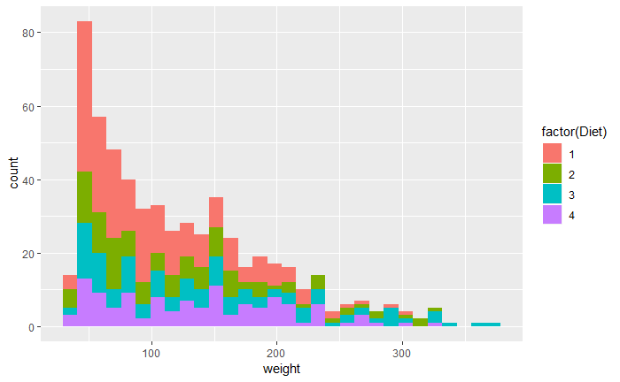

```r
ggplot(ChickWeight, aes(x=weight, fill=factor(Diet))) +
  geom_histogram()
```

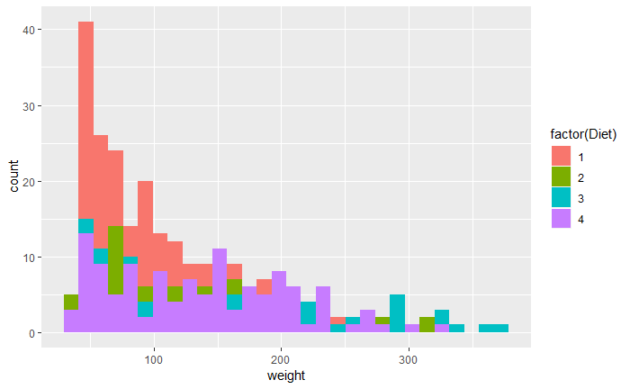

```r
#Possible values for the argument position are identity, stack, dodge. Default value is stack.
ggplot(ChickWeight, aes(x=weight, fill=factor(Diet))) +
  geom_histogram(position="identity")
```

- Density curve

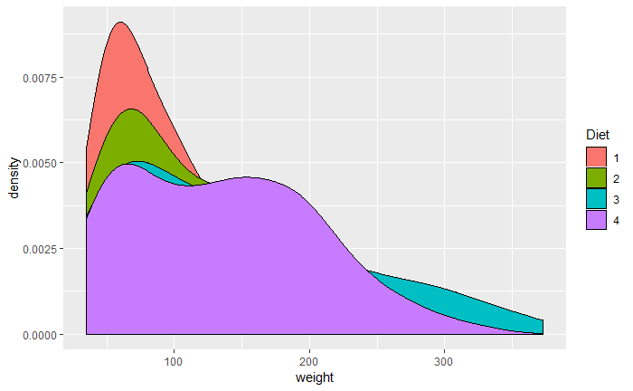

```r
ggplot(ChickWeight, aes(x=weight, fill=Diet)) + geom_density()
```

# Boxplot

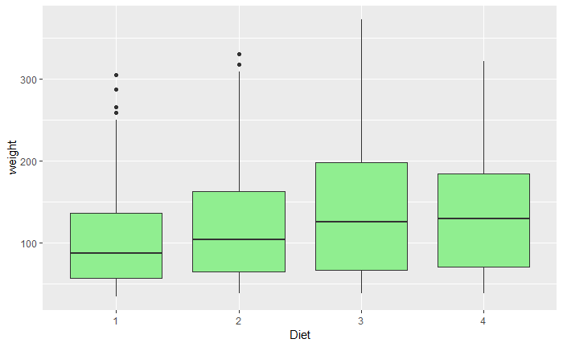

```r
ggplot(ChickWeight, aes(x=Diet, y=weight)) + geom_boxplot(fill="lightgreen")
```

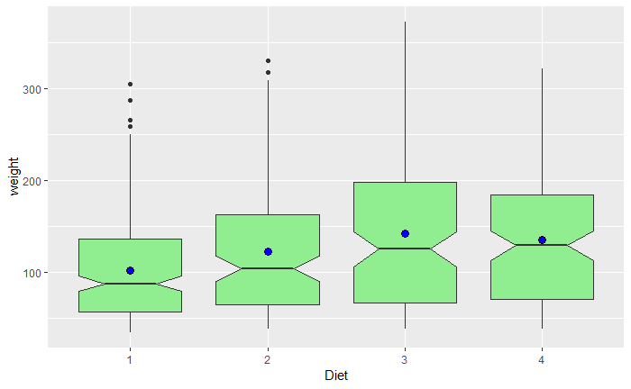

```r
ggplot(ChickWeight, aes(x=Diet, y=weight)) +
  geom_boxplot(fill="lightgreen", notch = TRUE) +
  stat_summary(fun.y="mean", geom="point", fill="blue", shape=21, size=3)
```

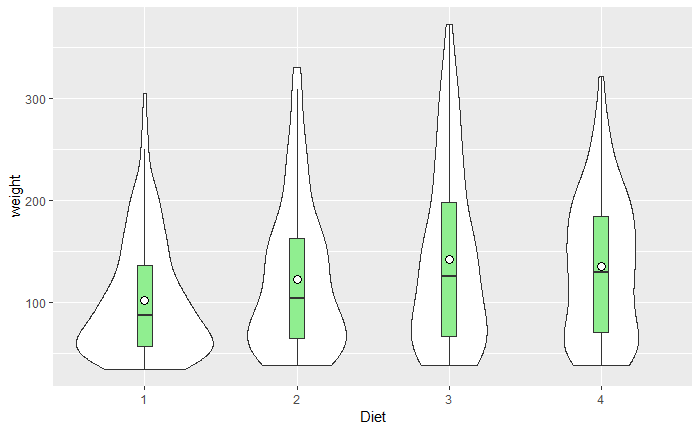

```r
ggplot(ChickWeight, aes(x=Diet, y=weight)) + geom_violin() +
  geom_boxplot(width=.1, fill="lightgreen", outlier.colour = NA) +
  stat_summary(fun.y="mean", geom="point", fill="white", shape=21, size=3)
```

# Change the overall appearance of the graph

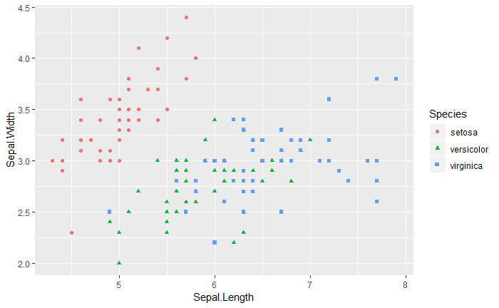

```r
bp <- ggplot(iris, aes(x=Sepal.Length, y=Sepal.Width, color=Species, shape=Species)) +
  geom_point()
bp
```

- Set background to be black and white

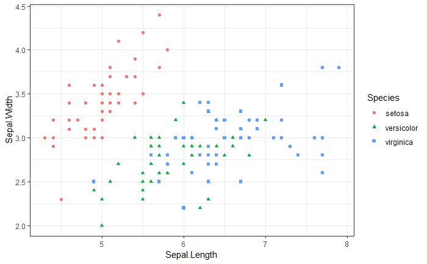

```r
bp1 <- bp + theme_bw()
bp1
```

- Remove grid lines

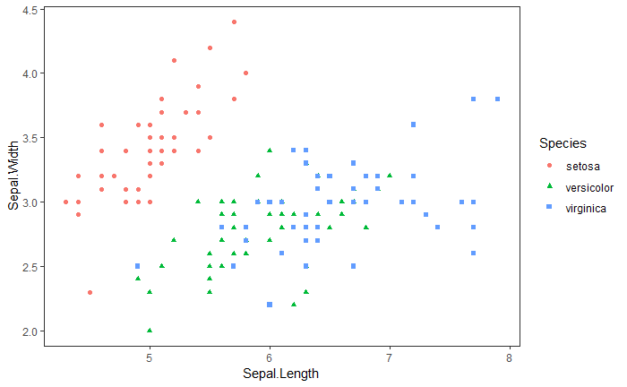

```r
bp2 <- bp1 + theme(panel.grid.major=element_blank(), panel.grid.minor = element_blank())
bp2
```

- Add labels

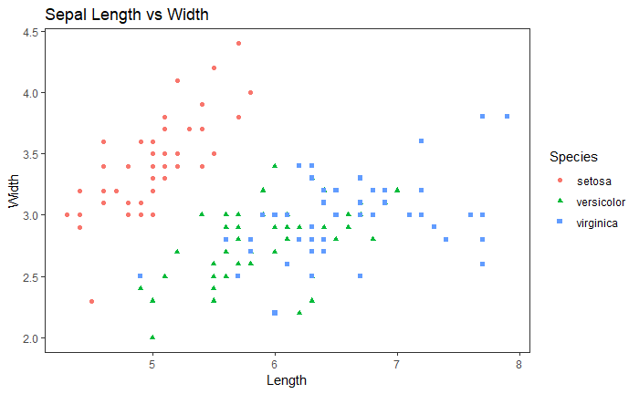

```r
bp3 <- bp2 + labs(x="Length", y="Width", title="Sepal Length vs Width")
bp3
```

- Modify title and axis labels

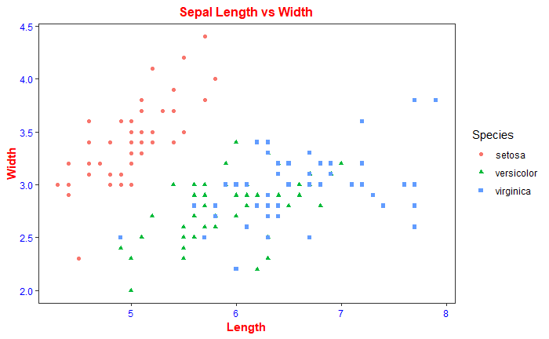

```r
bp4 <- bp3 +
  theme(axis.title = element_text(colour = "red", size=11, face = "bold"),
        axis.text.x=element_text(colour = "blue"),
        axis.title.y = element_text(colour = "red", size = 11, face = "bold", angle = 90),
        axis.text.y = element_text(colour = "blue"),
        plot.title = element_text(colour = "red", size=12, face = "bold", hjust=0.5))
bp4
```

- Modify legend

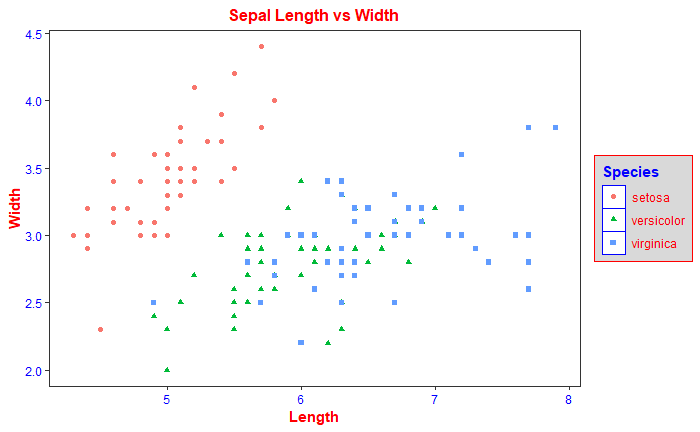

```r
bp4 +
  theme(legend.background = element_rect(fill = "gray85", colour = "red", size=0.2),
        legend.title = element_text(colour = "blue", face="bold", size = 11),
        legend.text = element_text(colour = "red"),
        legend.key = element_rect(colour = "blue", size=0.2))
```

# Pie chart

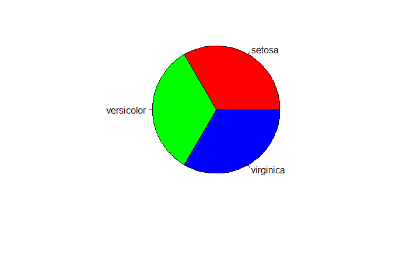

```r
pie(table(iris$Species), col=rainbow(3))
```

# Heatmap

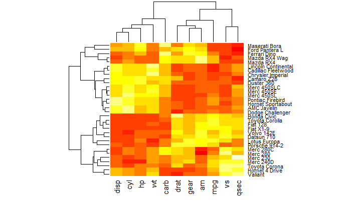

```r
data <- as.matrix(scale(mtcars))
heatmap(data)
```

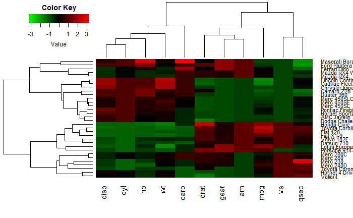

```r
data <- as.matrix(scale(mtcars))
library(gplots)
heatmap.2(data, col=greenred(100), trace="none", density.info="none")
```

- Venn Diagram

```
(polygon[GRID.polygon.1525], polygon[GRID.polygon.1526], polygon[GRID.polygon.1527], polygon[GRID.polygon.1528], text[GRID.text.1529], text[GRID.text.1530], text[GRID.text.1531], text[GRID.text.1532], text[GRID.text.1533])
```

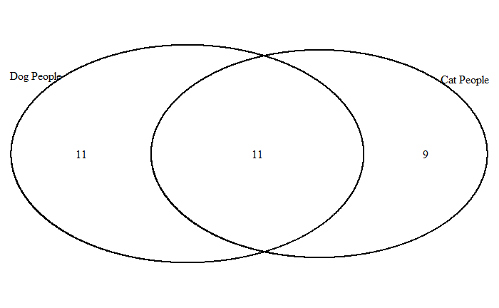

```r
# install.packages('VennDiagram')
library(VennDiagram)
grid.newpage()
draw.pairwise.venn(area1 = 22, area2 = 20, cross.area = 11, category = c("Dog People", "Cat People"))
```

```
(polygon[GRID.polygon.1534], polygon[GRID.polygon.1535], polygon[GRID.polygon.1536], polygon[GRID.polygon.1537], text[GRID.text.1538], text[GRID.text.1539], text[GRID.text.1540], text[GRID.text.1541], text[GRID.text.1542])
```

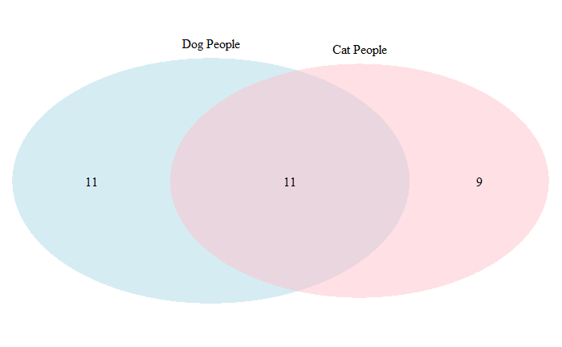

```r
grid.newpage()
draw.pairwise.venn(22, 20, 11, category = c("Dog People", "Cat People"),
                   lty = rep("blank", 2),
                   fill = c("light blue", "pink"),
                   alpha = rep(0.5, 2),
                   cat.pos = c(0,0), cat.dist = rep(0.025, 2))
```

# Correlation plot

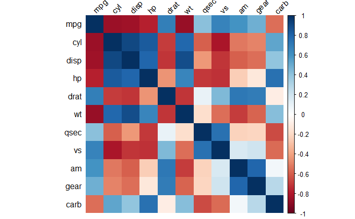

```r
#install.packages("corrplot")
library(corrplot)
mcor <- cor(mtcars)
corrplot(mcor, method="shade", shade.col=NA, tl.col="black", tl.srt=45)
```

# Output for publication or presentation

- Output to PNG

```r
png(filename = "ScatterPlot.png", width = 480, height = 480)
plot(pressure)
dev.off()
```

- Output to PDF

```r
pdf(file = "ScatterPlot.pdf", width = 4, height = 4)
plot(pressure)
dev.off()
```

# 10-Minute Break before Workshop